# Data Science Capstone Milestone Model

Gagan Deep Singh Chhabra

July 3, 2017

### Goal of Project …

The goal here is to build your first simple model for the relationship between words. This is the first step in building a predictive text mining application. You will explore simple models and discover more complicated modeling techniques.

### Tasks to perform

#### Dataset

Download from Coursera: https://d396qusza40orc.cloudfront.net/dsscapstone/dataset/Coursera-SwiftKey.zip

### Library Required

```r
library(tm)
```

### Quiz 1:

1.The en_US.blogs.txt file is how many megabytes?

Ans: <200MB>. Right Click on the the file and click on properties to check the size of the file.

2.The en_US.twitter.txt has how many lines of text?

Ans:

```r
twitter <- readLines(con <- file("D:/DataScientist/10. Cap Stone Project/Coursera-SwiftKey/final/en_US/en_US.twitter.txt"), encoding = "UTF-8", skipNul = TRUE)
close(con)
```

### Checking the length

```r
length(twitter)
```

```
## [1] 2360148
```

3.What is the length of the longest line seen in any of the three en_US data sets?

Ans: Read in the lines to arrays:

```r
fileName="D:/DataScientist/10. Cap Stone Project/Coursera-SwiftKey/final/en_US/en_US.blogs.txt"
con=file(fileName,open="r")
lineBlogs=readLines(con)
longBlogs=length(line)
close(con)

fileName="D:/DataScientist/10. Cap Stone Project/Coursera-SwiftKey/final/en_US/en_US.news.txt"
con=file(fileName,open="r")
lineNews=readLines(con)
longNews=length(line)
close(con)

fileName="D:/DataScientist/10. Cap Stone Project/Coursera-SwiftKey/final/en_US/en_US.twitter.txt"
con=file(fileName,open="r")
lineTwitter=readLines(con)
longTwitter=length(line)
close(con)

longBlogs = nchar(longBlogs)
max(nchar(longBlogs))
```

```
## [1] 1
```

```r
require(stringi)
longBlogs<-stri_length(lineBlogs)
max(longBlogs)
```

```
## [1] 40835
```

```r
longNews<-stri_length(lineNews)
max(longNews)
```

```
## [1] 5760
```

```r
longTwitter<-stri_length(lineTwitter)
max(longTwitter)
```

```
## [1] 213
```

4.In the en_US twitter data set, if you divide the number of lines where the word “love” (all lowercase) occurs by the number of lines the word “hate” (all lowercase) occurs, about what do you get?

Ans: <4> Get count of lines with “love” (case-sensitive), store in variable grep?

```r
# Word "love"
loveTwitter<-grep("love",lineTwitter)
lenlt <- length(loveTwitter)
# Word "hate"
hateTwitter<-grep("hate",lineTwitter)
lenht <- length(hateTwitter)
lenlt / lenht
```

```
## [1] 4.108592
```

5.The one tweet in the en_US twitter data set that matches the word “biostats” says what? As below

Ans:

```r
biostatsTwitter<-grep("biostats",lineTwitter)
lineTwitter[biostatsTwitter]
```

```
## [1] "i know how you feel.. i have biostats on tuesday and i have yet to study =/"
```

6.How many tweets have the exact characters “A computer once beat me at chess, but it was no match for me at kickboxing”. (I.e. the line matches those characters exactly.)

Ans: <3>

```r
sentenceTwitter<-grep("A computer once beat me at chess, but it was no match for me at kickboxing",lineTwitter)
length(sentenceTwitter)
```

```
## [1] 3
```

### 2.Data Cleaning

n-gram model (think Markov Chains)

```r
# Remove all weird characters
cleanedTwitter<- iconv(twitter, 'UTF-8', 'ASCII', "byte")
# Sample 10000
twitterSample<-sample(cleanedTwitter, 10000)
doc.vec <- VectorSource(twitterSample)
doc.corpus <- Corpus(doc.vec)
#Convert to lower case
doc.corpus<- tm_map(doc.corpus, tolower)
#Remove all punctuatins
doc.corpus<- tm_map(doc.corpus, removePunctuation)
#Remove all numbers
doc.corpus<- tm_map(doc.corpus, removeNumbers)
#Remove whitespace
doc.corpus <- tm_map(doc.corpus, stripWhitespace)
#Force everything back to plaintext document
doc.corpus <- tm_map(doc.corpus, PlainTextDocument)
```

### 3.Exploratory Analysis

#### Visualize using wordcloud

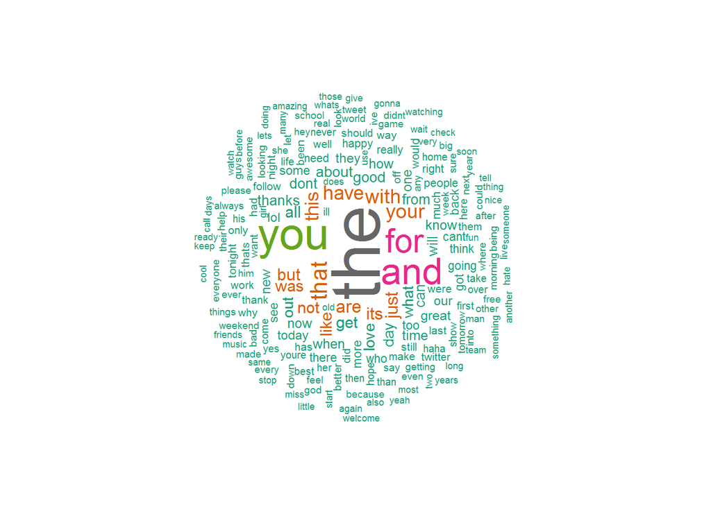

```r
library(wordcloud)
wordcloud(doc.corpus, max.words = 200, random.order = FALSE,rot.per=0.35, use.r.layout=FALSE,colors=brewer.pal(8, "Dark2"))
```

### 4.Future NLP project

This coming project is to be continue with building a predictive model. n-grams model (think Markov Chains) will be used to tokenize the words & frequency of tokens will be used in building the model. Finally a shiny app that will predict the next word following a given word typed in by user as input will be developed as a data product. And can run the predictive model much more faster.